# Using containers with Docker

Rockefeller University, Bioinformatics Resource Centre

https://rockefelleruniversity.github.io/RU_reproducibleR/

# Containers

## Set Up

All prerequisites, links to material and slides for this course can be found on github.

- [Reproducible_R](https://rockefelleruniversity.github.io/RU_reproducibleR/)

Or can be downloaded as a zip archive from here.

- [Download zip](https://github.com/RockefellerUniversity/RU_reproducibleR/archive/master.zip)

## Course materials

Once the zip file in unarchived. All presentations as HTML slides and pages, their R code and HTML practical sheets will be available in the directories underneath.

- **presentations/slides/** Presentations as an HTML slide show.
- **presentations/singlepage/** Presentations as an HTML single page.
- **presentations/r_code/** R code in presentations.
- **exercises/** Practicals as HTML pages.
- **answers/** Practicals with answers as HTML pages and R code solutions.
- **data/** Data used in this presentation.

# What are containers? Why should we use them?

## The problem

Something works on your computer (e.g. bioinformatics analysis or software deployment), and you want to make sure that it will work on another computer.

[figure not shown]

[https://jhudatascience.org/Adv_Reproducibility_in_Cancer_Informatics/launching-a-docker-image.html -](https://jhudatascience.org/Adv_Reproducibility_in_Cancer_Informatics/launching-a-docker-image.html) [CC-BY 4.0](https://creativecommons.org/licenses/by/4.0)

## The solution - Docker!

Docker allows for the creation of an isolated environment that can be shipped across different users, machines, or operating systems, and to virtual machines or the cloud.

[figure not shown]

[https://jhudatascience.org/Adv_Reproducibility_in_Cancer_Informatics/launching-a-docker-image.html -](https://jhudatascience.org/Adv_Reproducibility_in_Cancer_Informatics/launching-a-docker-image.html) [CC-BY 4.0](https://creativecommons.org/licenses/by/4.0)

## Docker client and host

Once installed on your computer, Docker runs a process called the Docker daemon. A daemon is a program that runs as a background process and is not under direct control of the computer user, and the Docker daemon is the engine that manages Docker services and objects by communicating with the client.

The Docker client, typically the command line interface, communicates with the Docker daemon based on [user commands.](https://docs.docker.com/engine/reference/commandline/cli/)

[figure not shown]

## Creating Docker images

The ‘docker image build’ command uses a Dockerfile to create an image.

A Docker image is a read-only, isolated file system that contains all software, dependencies, scripts, and metadata required to run a container.

[figure not shown]

## Launching Docker containers

Once an image is built, an instance of this image can be launched as a stand-alone application, also known as a container.

[figure not shown]

## Pulling Docker images

There are public repositories of Docker images (e.g. [Docker Hub](https://hub.docker.com/)), and typically you start with an existing image and build on top of this.

[figure not shown]

## Installing Docker

Use [this link](https://www.docker.com/get-started/) to install Docker.

- Click on the Docker desktop icon and make an account with Docker.
- Docker must be open and running to use the command line interface (CLI), which is how we will primarily use Docker.
- [See here](https://docs.docker.com/engine/reference/commandline/cli/) for Docker CLI commands.

Check Docker version to make sure Docker is installed and running.

*Code (terminal):*

```bash
docker --version
```

*Output:*

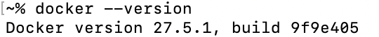

## Installing Docker

If previous command isn’t found check the Docker Desktop advanced settings and make sure CLI tools are available system-wide.

[figure not shown]

# Running Docker containers from Docker Hub images

## Pulling Docker images - Rocker

[Rocker](https://rocker-project.org/) is a very useful source of images on Docker Hub for R and RStudio. We can pull these images immediately after installing Docker. Here we pull an image containing RStudio and a specific version of R.

*Code (terminal):*

```bash
docker image pull rocker/rstudio:4.4.0
# alias of 'docker pull' from older Docker versions
```

## Viewing local Docker images

After pulling, the image is now available on our system to run.

Images have names, tags, and image IDs as shown in the output. The ID is a hash of the metadata and filesystem of the Docker image.

*Code (terminal):*

```bash
docker images
```

*Output:*

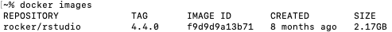

## Viewing local Docker images

After pulling, the image is now available on our system to run.

Images have names, tags, and image IDs as shown in the output. The ID is a hash of the metadata and filesystem of the Docker image.

We can also view the image in Docker desktop:

[figure not shown]

## Running Docker containers

Once the image is on our system, we can launch a container with the [‘docker container run’ command](https://docs.docker.com/engine/reference/commandline/run/).

Components of the run command: * –rm: this will automatically remove a container when you exit, otherwise can take up room on computer with old, unused containers * -p: before the colon is the port on your computer to be exposed and after the colon is the port inside the container * -e: an environmental variable is set when the container is run, and this will be the password to login * the last argument is the image name and tag (both seen with ‘docker images’)

*Code (terminal):*

```bash
docker container run --rm \
               -p 8787:8787 \
               -e PASSWORD=password123 \
               rocker/rstudio:4.4.0
# alias of 'docker run' from older Docker versions
```

## Running Docker containers

While the container is running, we can go to ‘http://localhost:8787’ in a browser and log in with the the user ‘rstudio’ and the password from ‘docker container run’.

[figure not shown]

## Listing active Docker containers

To see all containers running in the local environment, use the ‘docker container ls’ command

*Code (terminal):*

```bash
docker container ls
# alias of 'docker ps' from older Docker versions
```

*Output:*

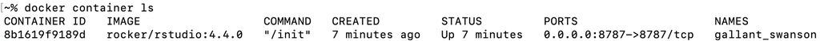

## Stopping Docker containers

To stop the container currently running, if you are in the terminal tab where it was launched press Ctrl+C.

Or open up another tab and the ‘docker stop’ command can be used with the ID listed from ‘docker container ls’

*Code (terminal):*

```bash
docker container stop 8b1619f9189d # this is the ID from 'docker container ls'
docker container ls
```

*Output:*

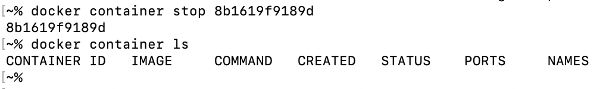

## Adding volumes to containers

The docker container has it’s own file system, and we can mount a local directory onto that file system with the ‘-v’ flag for the ‘docker container run’ command.

- Navigate to the ‘r_course’ directory within the downloaded course using the ‘cd’ command in the terminal
- Use the ‘docker container run’ command with the ‘-v’ flag
  - the left side of the colon is the path on your computer to mount
  - the right side is the location within the docker container file system where that data will be accessible
  - ‘/home/rstudio’ is set by the container to be the working directory of Rstudio

*Code (terminal):*

```bash
# navigate to 'r_course' directory in downloaded material
 cd ~/Downloads/RU_reproducibleR-master/r_course

 # launch docker container
 docker container run --rm \
          -v ./data:/home/rstudio \
          -p 8787:8787 \
           -e PASSWORD=password123 \
           rocker/rstudio:4.4.0
```

## Adding volumes to containers

The RStudio interface now shows the files in the ‘data’ directory

[figure not shown]

## Adding volumes to containers

These files can be read into R, and also files can be written to the local environment

*Code (R in docker image):*

```r
dataIn <- read.csv("readThisTable.csv")
head(dataIn, 2)
# add gene IDs and write to new file on local computer
dataIn$Gene_ID <- seq(nrow(dataIn))
write.csv(dataIn, "rnaseq_table_withIDs.csv")
```

## Adding volumes to containers

These files can be read into R, and also files can be written to the local environment

*Output:*

[figure not shown]

## Adding volumes to containers

In addition to the files deliberately written to the local directory, the R environment files from this RStudio session are written to the working directory in the container, and therefore are copied to the local directory as hidden folders (.config and .local).

This R environment will then be loaded the next time you launch an RStudio container with this volume mounted. While this is normally okay, if desired a fresh RStudio session can be launched with the same mounted volume by removing these hidden directories.

*Code (terminal):*

```bash
# For windows use: dir /a
ls -a data
rm -r data/.local data/.config
```

*Output:*

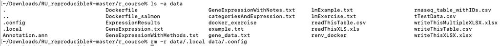

# Building custom images from a Dockerfile

## Dockerfile basics and commands

The image we pull from Rocker contains base R and its associated packages. To customize the image, we will need to make a Dockerfile that adds to the Rocker image.

A Dockerfile provides the recipe to make the image. Using [specialized commands](https://docs.docker.com/engine/reference/builder/), this file provides instructions to install the R packages and its dependencies.

Some examples: * FROM: sets the base image and further instructions build off of this * RUN: executes a command as if in terminal * LABEL: add metadata to the image * COPY: copies files from the the host system to the image file system * CMD: when the container is launched, this is the command that will be run

## Dockerfile components

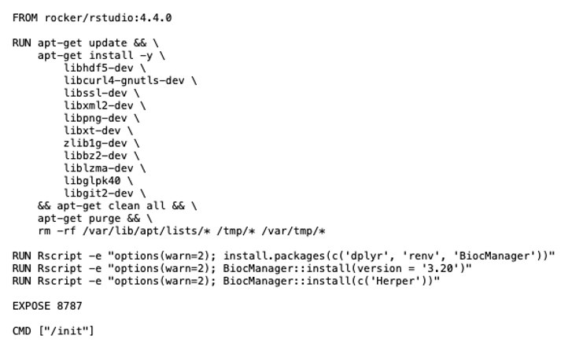

## Dockerfile components

Here we start with the same RStudio base image we used previously, and then add some key R packages.

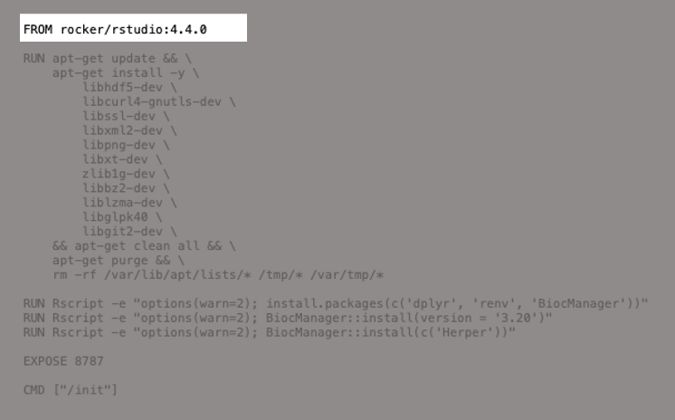

## Dockerfile components

The first RUN command installs system dependencies that are common to R packages. This command looks for updates, installs, and cleans up unnecessary files.

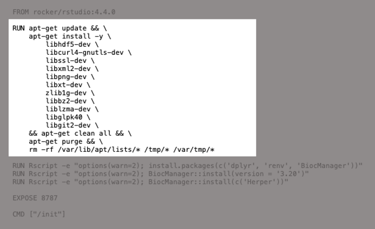

## Dockerfile components

This is a list of libraries is not comprehensive and adding more R packages could result in missing dependencies.

These can be identified in the log for the build command and manually added to the *apt-get* command, or alternatively, dependencies for a specific R or Python package can be found using the [Posit package manager](https://packagemanager.posit.co). This resource can also be used to install only those libraries that are necessary, which can help to limit the size of the image.

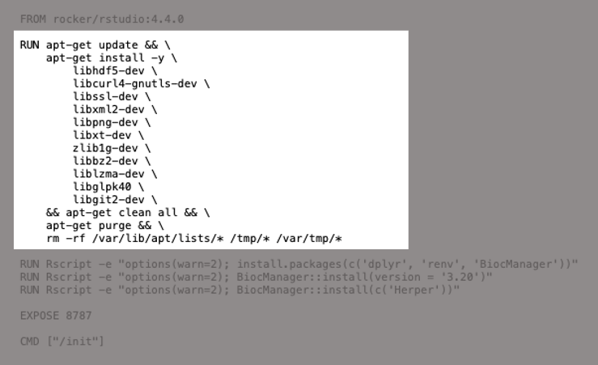

## Dockerfile components

Then the R packages are installed using ‘install.packages’ or ‘BiocManager::install’ for Bioconductor packages.

Note: The ‘options(warn=2)’ at the beginning of the R command will stop the installation when there is a warning, making it easier to debug.

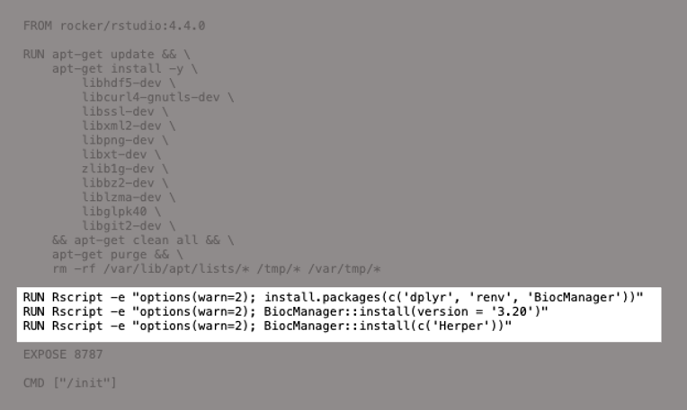

## Dockerfile components

The port 8787 is exposed and the ‘init’ script that is included with the base RStudio image. These commands are specific to this image and will vary depending on what the Docker container is meant to do when launched.

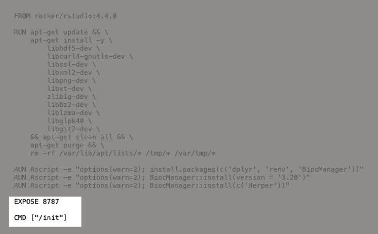

## Building an image with a Dockerfile

- A tag is added to distinguish this image
- The directory that contains the Dockerfile is the last argument
- If no file name is given, it will look for a file called ‘Dockerfile’
  - ‘Dockerfile’ is in the data directory of course materials

*Code (terminal):*

```bash
cd ~/Downloads/RU_reproducibleR-master/r_course
docker image build -t rocker/rstudio:4.4.0_v2 ./data
```

*Output:*

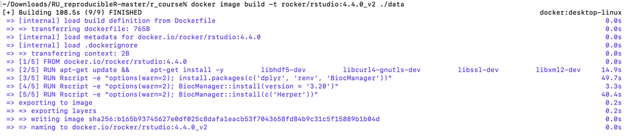

## Building an image with a Dockerfile

Use the *docker images* command to see image

*Code (terminal):*

```bash
docker images
```

*Output:*

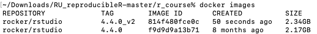

## Running the custom container

As done previously, use the *docker container run* command to launch a container with our customized RStudio session

*Code (terminal):*

```bash
docker container run --rm \
          -v ./data:/home/rstudio \
          -p 8787:8787 \
           -e PASSWORD=password123 \
           rocker/rstudio:4.4.0_v2
```

## Running the custom container

As done previously, use the *docker container run* command to launch a container with our customized RStudio session

*Output:*

[figure not shown]

# Install conda packages in a Docker image

## Use Herper for conda packages

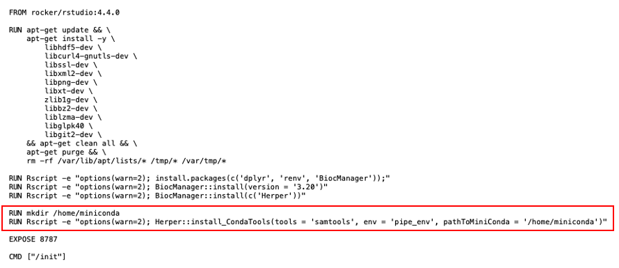

## Use Herper for conda packages

The directory that contains the Dockerfile is the last argument

This Dockerfile is not named ‘Dockerfile’, so we specify the exact path with ‘-f’ argument

*Code (terminal):*

```bash
docker image build -t rocker/rstudio:4.4.0_samtools -f ./data/Dockerfile_samtools ./data/
```

*Output:*

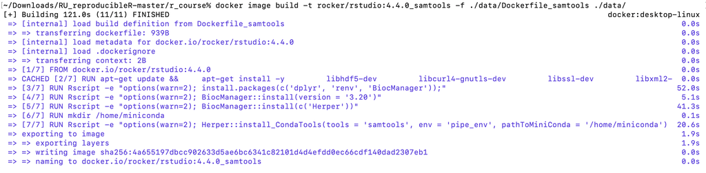

## Use Herper for conda packages

*Code (terminal):*

```bash
docker images
```

*Output:*

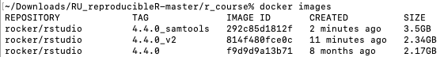

*Code (terminal):*

```bash
docker container run --rm \
          -v ./data:/home/rstudio \
          -p 8787:8787 \
           -e PASSWORD=password123 \
           rocker/rstudio:4.4.0_samtools
```

## Use Herper for conda packages

*Code (R in docker image):*

```r
library(Herper)
# the environment name and miniconda path set in the Dockerfile
Herper::local_CondaEnv(new = "pipe_env",
                       pathToMiniConda = "/home/miniconda")
# test out samtools
system("samtools --help")
```

*Output:*

[figure not shown]

# Run container from Docker Desktop

## Run container from Docker Desktop

We can also run containers from Docker Desktop

[figure not shown]

## Run container from Docker Desktop

We can also run containers from Docker Desktop

[figure not shown]